# Zaman Serileri Analizine Giriş

# 3 Zaman Serisi Ekonometrisi Analizleri

Zaman serisi ekonometrisi analizlerinden önce kullanılan terimler ve varsayımların net bir şekilde öğrenilmesi gereklidir.

## 3.1 Durağanlık, Rassal Yürüyüş, Akgürültü

**Durağanlık(Stationary):** Ortalaması, varyansı ve çeşitli gecikmelerdeki ortak varyansı ne zaman ölçülürse ölçülsün aynı sonucu veren serilerin yapısal durumudur. Durağan bir seri deterministik öğelerden arındırılmış olmalı başka bir ifade ile **stokastik/rassal süreçte** olmalıdır.

**Rassal Yürüyüş(Random Walk):** Stokastik yani rassal zaman serilerinde bulunmaktadır. Seri, direk geçmiş değerleri ile yüksek ilişkilidir.

$$Y_t = Y_{t-1} + e_t$$

**Akgürültü (White Noise):** Hata terimleri sıfır ortalama, sabit varyans ile normal dağılan durağan süreçtir. Yukarıdaki modelin hata terimlerinde White noise mevcuttur.

## 3.2 Durağanlık Analizi

Zaman serileri çözümlemesinde serilerin durağan olması önemlidir, çünkü bir seri eğer durağan değilse farklı veri setlerinde farklı görüntüler sergilemektedir. Bu durumda serinin davranışı diğer dönemlere genellenememekte ve geleceği tahmin etmek için etkin bir şekilde faydalı olmamaktadır.

Klasik regresyon modeli durağan değişkenler arasındaki ilişkilerde kullanılmak üzere geliştirilmiştir. Bu nedenle durağan olmayan serilerde klasik regresyon modeli çalışıldığında güvenilir sonuçlar üretmemektedir.

Durağan olmama durumu, grafikten ve korelogramdan anlaşılabilmektedir. Ancak daha hassas bir analiz için **Dickey Fuller Birim Kök** testleri uygulanması gereklidir. Durağan olmama durumunun tespit edilmesi ile fark alma işlemi yapılarak serinin rassal yürüyüş sürecinden arındırılması gereklidir.

Durağanlığın kontrolü için öncelikle serinin zaman bileşenleri ayrıştırılmalı başka bir ifade ile sezonsallık, trend ve konjoktür etkilerinden arındırılması gereklidir. Bu etkilerden arındırılan seriye durağanlık testleri yapılmalıdır.

## 3.3 Otokorelasyon ve Korelogram

**Otokorelasyon (Auto Correlation):** Korelasyon, iki değişken arasındaki doğrusal ilişkinin ölçüsünü ölçerken, otokorelasyon bir zaman dizisinin gecikme değerleri arasındaki doğrusal ilişkiyi ölçer .Örneğin $r_1$, $y_t$ ile $y_{t-1}$ arasındaki ilişkiyi ölçer. r2, yt-1, yt-2 arasındaki ilişkiyi gösterir ve fonksiyon,

$$r_k ={\sum_{t=k+1}^T (y_t - y )(y_{t-k}-y)}/{ \sum_{t+1}^T (y_t - y)^2 }$$

**Korelogram (Correlogram/ACF):** Otokorelasyon fonksiyonu grafiğidir.

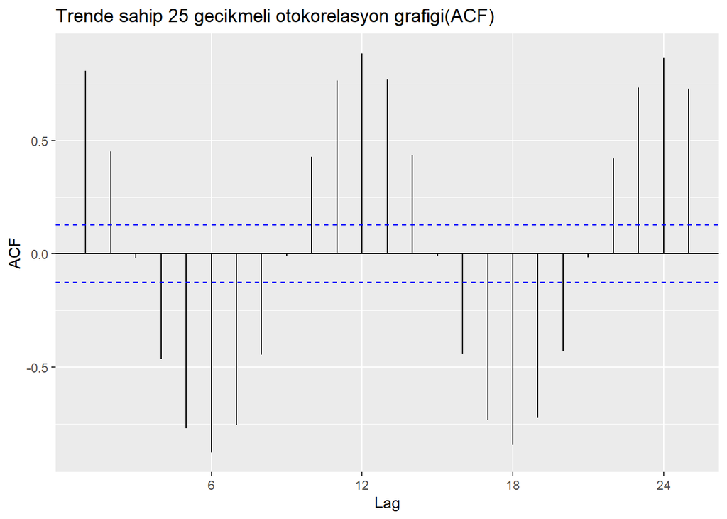

```r
ggAcf(nottem, lag.max=25) +ggtitle("Trende sahip 25 gecikmeli otokorelasyon grafiği(ACF)") #lag.max gecikma sayısını gösterir
```

**ACF Korelogram Değerlendirmeleri:** - Gecikme sayısı 25 olan ACF grafiği. Mavi çizgiler güven sınırlarını gösterir.Yukarıdaki ACF grafiğine baktığımızda Trende sahip bir verinin ACF grafiğini görmekteyiz. İlk 4 gecikme güven sınırları dışındaysa trendin olduğunu söyleyebiliriz.  
- Korelogramda yer alan ilk gecikme, serinin kendisi olduğu için 1 sonucu vermekte ve bu sebeple ölçüm kriteri olarak değerlendirilmemektedir.  
- Otorkoreasyon olup olmadığı, ACF korelogramından tespit edilebilmektedir. Korelogramın pozitif tarafındaki gecikme değerleri değerlendirilir ve güven aralıklarının dışında kalan gecikme çizgileri var ise seri otokorelasyona sahiptir.  
- Güven aralığı dışında herhangi bir gecikme çizgisi yok ise seride otokorelasyon yoktur.  
- Korelogramda görülen tepelerdeki gecikme derecesi ile serinin ilişkisi yüksek olduğu söylenebilir.  
- Eğer çok yüksek bir değerden başlayıp çok yavaş küçülüyorsa, bu serinin durağan olmadığının bir göstergesidir.  
- MA(q) süreci hakkında bilgi verir.

**Kısmi Otokorelasyon (Partial Correlogram/PACF):** Serinin kendi otokorelasyonun gecikmeli değeri ile ilişkisinin fonkisyon grafiğidir. tüm kısa süreli gecikmelerde zaman serilerinin değerlerini kontrol eder ve fonksiyon,

$$r_{kk} ={r_k-\sum_{j=1}^{k-1} (r_{k-1,j})(r_{k-j})}/{1-\sum_{j=1}^{k-1} (r_{k-1,j})(r_j) }$$

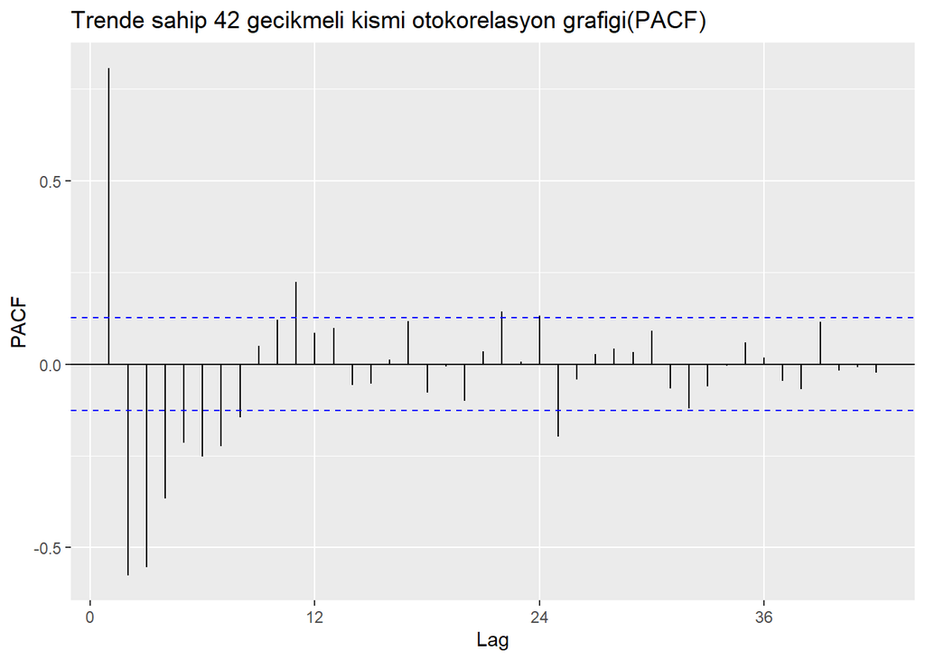

```r
ggPacf(nottem, lag.max = 42) +ggtitle("Trende sahip 42 gecikmeli kısmi otokorelasyon grafiği(PACF)")
```

**PACF Korelogram Değerlendirmeleri:**

- Kısmi otokoreasyon olup olmadığı, PACF korelogramından tespit edilebilmektedir. Korelogramın negatif tarafındaki gecikme değerleri değerlendirilir ve güven aralıklarının dışında kalan gecikme çizgileri var ise seri kısmi otokorelasyona sahiptir.
- Güven aralığı dışında herhangi bir gecikme çizgisi yok ise seride kısmi otokorelasyon yoktur.
- Korelogramda görülen tepelerdeki gecikme derecesi ile serinin ilişkisi yüksek olduğu söylenebilir.
- Eğer çok yüksek bir değerden başlayıp çok yavaş küçülüyorsa, bu serinin durağan olmadığının bir göstergesidir.
- AR(p) süreci hakkında bilgi verir.

## 3.4 Birim Kök

Rassal yürüyüşteki bir serinin, geçmiş değerleri ile **tam** ilişkili olduğunda, seri **Birim Kök (Unit Root)** sahiptir. Birim köke sahip seriler durağan değildir. Bu sonuç ile durağanlık birim kök testleri ile tespit edilebilmektedir.

Bu çalışmada birim kök testi olarak **Dickey-Fuller** testi kullanılmaktadır. Birim kök testinde serinin kendi geçmiş değeri ile açıklandığında katsayının 1 olup olmadığı test edilir.

$$Y_t = \rho Y_{t-1} + e_t\hspace{5mm} ,\hspace{5mm} -1 <\rho <1$$
**Hipotez testi:**

$$H_0 = Birim\hspace{2mm} kök\hspace{2mm} vardır.\\
H_a = Birim\hspace{2mm} kök\hspace{2mm} yoktur.$$

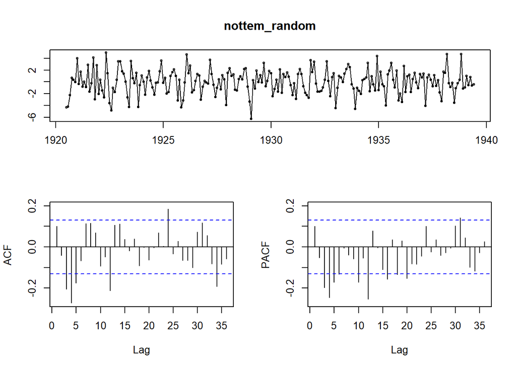

```r
nottem_random=decompose(nottem)$random   #1920 - 1939 Yılları Arasında Nottingham'da ki Aylık Ortalama Sıcaklık
nottem_random=na.remove(nottem_random)

tsdisplay(nottem_random)
```

```r
adf.test(nottem_random)
```

```
##
##  Augmented Dickey-Fuller Test
##
## data:  nottem_random
## Dickey-Fuller = -8.4454, Lag order = 6, p-value = 0.01
## alternative hypothesis: stationary
```

Dickey Fuller test sonucu p-değeri < 0.05 olduğu için, **nottem** serisinin mevsim bileşenlerinden arındırılmış halinde birim kök yoktur. Bu aşamadan sonra Zaman Serileri modelleri yöntemleri uygulabilir.

# 4 Zaman Serisi Ekonometrik Modeller

Zaman serisi ekonometrisi modelleri Doğrusal *(Linear)* ve Doğrusal Olmayan *(Non-Linear)* olarak ikiye ayrılmaktadır.

Bunlar;

| **Doğrusal Modeller** | **Doğrusal Olmayan Modeller** |
| --- | --- |
| Üstel Düzeltme *(Exponential Smoothing)* | Yapay Sinir Ağları *(Neural Networks)* |
| ARIMA *(Autoregressive Integrated Moving Average)* | Destek Vektör Makinesi *(Support Vector Machines)* |
| Mevsimsel Ayrıştırma *(Seasonal Decomposition)* | Kümeleme *(Clustering)* |
| Doğrusal Regresyon *(Lineear Regression)* |  |
| Vektör Otoregrsif Model *(Vector Autoregressive Model)* |  |

## 4.1 AR(p) - Otoregresif Süreç *(Autoregressive)*

Bağımlı değişkenin, kendi gecikmeli değerleri ile açıklandığı süreçtir. Otoregresif bir modeldir ve random walk sürecini de kapsamaktadır.

**AR(p) :** p mertebeden otoregresif süreci gösterir.

$$Y_t = \alpha_0 + \alpha_1 Y_{t-1} +\alpha_2 Y_{t-2}+ \alpha_3 Y_{t-3} + ....+ \alpha_p Y_{t-p} + e_t$$
**Örnek 10:**

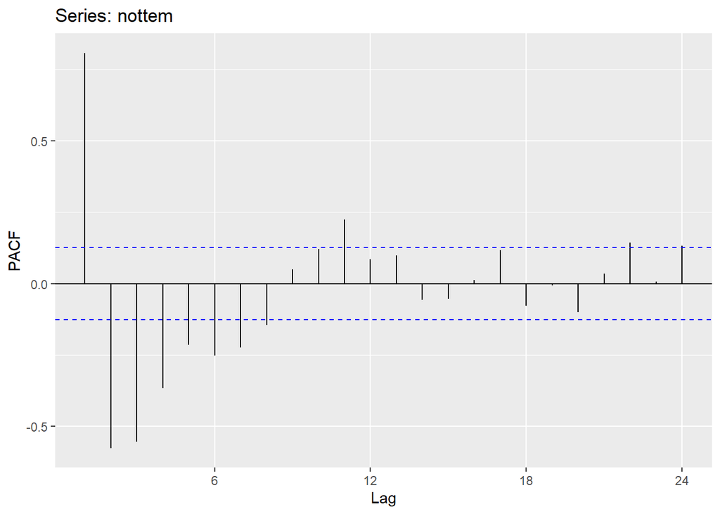

```r
ggPacf(nottem)
```

## 4.2 MA(q) - Hareketli Ortalama *(Moving Average)*

Serinin, gecikmeli hata terimi ile açıklandığı süreçtir.Hata terimleri; sıfır ortalama, sabit varyans ve normal dağılıma uygundur.

**MA(q) :** q mertebeden hareketli ortalamaları gösterir. Burada, X(t), e(t) ve e(t-1) in ağırlıklı ortalamasıdır.

$$Y_t = \theta_0 + e_t + \theta_1 e_{t-1} + \theta_2 e_{t-2} + \theta_3 e_{t-3} + ....+ \theta_q e_{t-q}$$
**Örnek 11:**

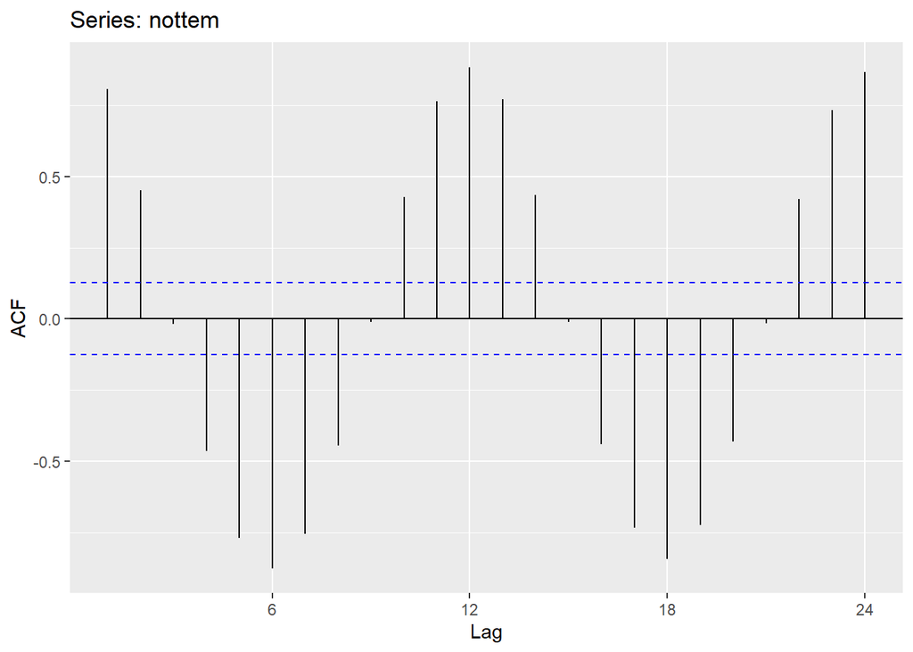

```r
ggAcf(nottem)
```

## 4.3 ARMA(p,q) *(Autoregresive Moving Average)*

Çoğu zaman serisi hem **AR** hem de **MA** sürecini içermektedir. Bu süreçlerde de **ARMA** denklemi kullanılmaktadır. Box-Jenkins yöntemleri de denilmektedir.

**ARMA(p,q) :** p mertebeden otoregresif süreci; q mertebeden hareketli ortalamaları gösterir.

$$Y_t = \alpha_0 + \alpha_1 Y_{t-1} +\alpha_2 Y_{t-2}+ \alpha_3 Y_{t-3} +....+ \alpha_p Y_{t-p} + e_t + \theta_1 e_{t-1} + \theta_2 e_{t-2} + \theta_3 e_{t-3} + ....+ \theta_q e_{t-q}$$

## 4.4 ARIMA(p,d,q) *(Autoregressive Integrated Moving Average)*

**ARMA(p,q)** sürecine entegrasyon **I(d)** sürecinin eklenmesiyle otoregresif entegre hareketli ortalama **ARIMA(p,d,q)** süreci geliştirilmiştir.

**I(d) :** d derecesinden serinin durağanlığı gösterilmektedir.

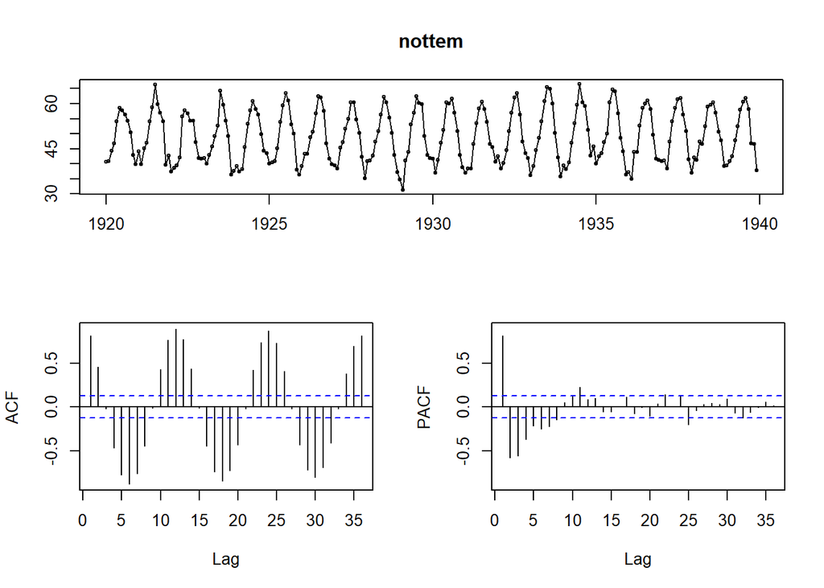

```r
tsdisplay(nottem)
```

```r
arima(nottem, order=c(2,0,0))
```

```
##
## Call:
## arima(x = nottem, order = c(2, 0, 0))
##
## Coefficients:
##          ar1      ar2  intercept
##       1.3044  -0.6026    48.9367
## s.e.  0.0516   0.0516     0.8617
##
## sigma^2 estimated as 15.87:  log likelihood = -673.3,  aic = 1354.6
```

```r
arima(nottem, order=c(2,2,2))
```

```
##
## Call:
## arima(x = nottem, order = c(2, 2, 2))
##
## Coefficients:
##           ar1      ar2     ma1     ma2
##       -0.3596  -0.2589  0.0187  0.3882
## s.e.   0.3461   0.1968  0.3323  0.1439
##
## sigma^2 estimated as 25.23:  log likelihood = -721.98,  aic = 1453.96
```

```r
arima(nottem, order=c(0,0,3))
```

```
##
## Call:
## arima(x = nottem, order = c(0, 0, 3))
##
## Coefficients:
##          ma1     ma2     ma3  intercept
##       0.9972  0.8726  0.5304    48.9163
## s.e.  0.0589  0.0512  0.0606     0.9147
##
## sigma^2 estimated as 17.55:  log likelihood = -685.27,  aic = 1380.54
```

Farklı modellerden hangisinin tercih edilmesi gerektiği **AIC** gibi başarı kriterleri karşılaştırılarak karar verilmektedir. Yukarıda gecikme mertebeleri kullanıcı tarafından karar verilip tahmin edilen 3 adet ARIMA modeli çalışılmıştır. Bu 3 modelin AIC kriterleri karşılaştırıldığında başarılı olan model ARIMA(2,0,0) modelidir.

Veri görselleştirilemeyecek kadar büyük veya serilerin sayısı çok olduğunda tek tek ACF/PACF kontrolleri yapılamaz hale gelmektedir. Bu durumda gecikme mertebelerini analist seçememektedir. Bu durumlarda **auto.arima()** fonksiyonu oldukça faydalı hale gelmektedir. Model otokorelasyonu, hataları ve başarı kriterlerine göre, otomatik olarak mertebeleri seçerek en iyi sonucu vermektedir. Farklı parametlerle ile üretilen sonuç değişebilmektedir.

```r
auto.arima(nottem)
```

```
## Series: nottem
## ARIMA(1,0,2)(1,1,2)[12] with drift
##
## Coefficients:
##          ar1     ma1     ma2     sar1     sma1     sma2  drift
##       0.1562  0.0898  0.1113  -0.5324  -0.4925  -0.2391  0.004
## s.e.  0.3699  0.3651  0.1139   0.1911   0.2071   0.1880  0.004
##
## sigma^2 estimated as 5.22:  log likelihood=-516.48
## AIC=1048.96   AICc=1049.62   BIC=1076.4
```

```r
auto.arima(nottem, trace=T)
```

```
##
##  Fitting models using approximations to speed things up...
##
##  ARIMA(2,0,2)(1,1,1)[12] with drift         : 1014.24
##  ARIMA(0,0,0)(0,1,0)[12] with drift         : 1183.648
##  ARIMA(1,0,0)(1,1,0)[12] with drift         : 1039.631
##  ARIMA(0,0,1)(0,1,1)[12] with drift         : 1031.964
##  ARIMA(0,0,0)(0,1,0)[12]                    : 1181.626
##  ARIMA(2,0,2)(0,1,1)[12] with drift         : 1035.609
##  ARIMA(2,0,2)(1,1,0)[12] with drift         : Inf
##  ARIMA(2,0,2)(2,1,1)[12] with drift         : Inf
##  ARIMA(2,0,2)(1,1,2)[12] with drift         : Inf
##  ARIMA(2,0,2)(0,1,0)[12] with drift         : 1181.515
##  ARIMA(2,0,2)(0,1,2)[12] with drift         : 1030.13
##  ARIMA(2,0,2)(2,1,0)[12] with drift         : 1025.221
##  ARIMA(2,0,2)(2,1,2)[12] with drift         : Inf
##  ARIMA(1,0,2)(1,1,1)[12] with drift         : 1011.371
##  ARIMA(1,0,2)(0,1,1)[12] with drift         : 1038.69
##  ARIMA(1,0,2)(1,1,0)[12] with drift         : 1038.522
##  ARIMA(1,0,2)(2,1,1)[12] with drift         : 1018.977
##  ARIMA(1,0,2)(1,1,2)[12] with drift         : 1003.395
##  ARIMA(1,0,2)(0,1,2)[12] with drift         : 1031.361
##  ARIMA(1,0,2)(2,1,2)[12] with drift         : 1009.551
##  ARIMA(0,0,2)(1,1,2)[12] with drift         : 1012.871
##  ARIMA(1,0,1)(1,1,2)[12] with drift         : 1007.346
##  ARIMA(1,0,3)(1,1,2)[12] with drift         : 1004.209
##  ARIMA(0,0,1)(1,1,2)[12] with drift         : 1014.321
##  ARIMA(0,0,3)(1,1,2)[12] with drift         : 1013.888
##  ARIMA(2,0,1)(1,1,2)[12] with drift         : Inf
##  ARIMA(2,0,3)(1,1,2)[12] with drift         : Inf
##  ARIMA(1,0,2)(1,1,2)[12]                    : 1003.931
##
##  Now re-fitting the best model(s) without approximations...
##
##  ARIMA(1,0,2)(1,1,2)[12] with drift         : 1049.621
##
##  Best model: ARIMA(1,0,2)(1,1,2)[12] with drift
```

```
## Series: nottem
## ARIMA(1,0,2)(1,1,2)[12] with drift
##
## Coefficients:
##          ar1     ma1     ma2     sar1     sma1     sma2  drift
##       0.1562  0.0898  0.1113  -0.5324  -0.4925  -0.2391  0.004
## s.e.  0.3699  0.3651  0.1139   0.1911   0.2071   0.1880  0.004
##
## sigma^2 estimated as 5.22:  log likelihood=-516.48
## AIC=1048.96   AICc=1049.62   BIC=1076.4
```

Eğer tüm mertebeleri kartezyen olarak deneyerek otomatik model tercihi yapılması isteniyorsa, aşağıdaki gibi **stepwise** deaktif edilir.

```r
auto.arima(nottem, trace=T, stepwise = F)
```

```
##
##  Fitting models using approximations to speed things up...
##
##  ARIMA(0,0,0)(0,1,0)[12]                    : 1181.626
##  ARIMA(0,0,0)(0,1,0)[12] with drift         : 1183.648
##  ARIMA(0,0,0)(0,1,1)[12]                    : 1040.549
##  ARIMA(0,0,0)(0,1,1)[12] with drift         : 1041.509
##  ARIMA(0,0,0)(0,1,2)[12]                    : 1034.895
##  ARIMA(0,0,0)(0,1,2)[12] with drift         : 1036.122
##  ARIMA(0,0,0)(1,1,0)[12]                    : 1058.317
##  ARIMA(0,0,0)(1,1,0)[12] with drift         : 1060.349
##  ARIMA(0,0,0)(1,1,1)[12]                    : 1038.901
##  ARIMA(0,0,0)(1,1,1)[12] with drift         : 1040.963
##  ARIMA(0,0,0)(1,1,2)[12]                    : 1027.048
##  ARIMA(0,0,0)(1,1,2)[12] with drift         : 1029.095
##  ARIMA(0,0,0)(2,1,0)[12]                    : 1032.101
##  ARIMA(0,0,0)(2,1,0)[12] with drift         : 1033.74
##  ARIMA(0,0,0)(2,1,1)[12]                    : 1027.413
##  ARIMA(0,0,0)(2,1,1)[12] with drift         : 1026.85
##  ARIMA(0,0,0)(2,1,2)[12]                    : 1018.709
##  ARIMA(0,0,0)(2,1,2)[12] with drift         : 1018.385
##  ARIMA(0,0,1)(0,1,0)[12]                    : 1176.715
##  ARIMA(0,0,1)(0,1,0)[12] with drift         : 1178.757
##  ARIMA(0,0,1)(0,1,1)[12]                    : 1030.731
##  ARIMA(0,0,1)(0,1,1)[12] with drift         : 1031.964
##  ARIMA(0,0,1)(0,1,2)[12]                    : 1023.837
##  ARIMA(0,0,1)(0,1,2)[12] with drift         : 1025.298
##  ARIMA(0,0,1)(1,1,0)[12]                    : 1041.416
##  ARIMA(0,0,1)(1,1,0)[12] with drift         : 1043.465
##  ARIMA(0,0,1)(1,1,1)[12]                    : 1022.255
##  ARIMA(0,0,1)(1,1,1)[12] with drift         : 1024.343
##  ARIMA(0,0,1)(1,1,2)[12]                    : 1012.239
##  ARIMA(0,0,1)(1,1,2)[12] with drift         : 1014.321
##  ARIMA(0,0,1)(2,1,0)[12]                    : 1018.904
##  ARIMA(0,0,1)(2,1,0)[12] with drift         : 1020.715
##  ARIMA(0,0,1)(2,1,1)[12]                    : 1014.962
##  ARIMA(0,0,1)(2,1,1)[12] with drift         : 1015.324
##  ARIMA(0,0,1)(2,1,2)[12]                    : 1007.156
##  ARIMA(0,0,1)(2,1,2)[12] with drift         : 1007.764
##  ARIMA(0,0,2)(0,1,0)[12]                    : 1174.804
```

[output cut: 147 more lines]

```
##  ARIMA(4,0,0)(0,1,1)[12]                    : 1042.642
##  ARIMA(4,0,0)(0,1,1)[12] with drift         : 1044.305
##  ARIMA(4,0,0)(1,1,0)[12]                    : 1041.371
##  ARIMA(4,0,0)(1,1,0)[12] with drift         : 1043.432
##  ARIMA(4,0,1)(0,1,0)[12]                    : 1183.066
##  ARIMA(4,0,1)(0,1,0)[12] with drift         : 1185.194
##  ARIMA(5,0,0)(0,1,0)[12]                    : 1184.015
##  ARIMA(5,0,0)(0,1,0)[12] with drift         : 1186.143
##
##  Now re-fitting the best model(s) without approximations...
##
##
##
##
##  Best model: ARIMA(1,0,1)(1,1,2)[12]
```

```
## Series: nottem
## ARIMA(1,0,1)(1,1,2)[12]
##
## Coefficients:
##          ar1      ma1     sar1     sma1     sma2
##       0.4550  -0.1963  -0.5490  -0.4670  -0.2416
## s.e.  0.1857   0.2029   0.1793   0.1953   0.1763
##
## sigma^2 estimated as 5.224:  log likelihood=-517.25
## AIC=1046.49   AICc=1046.87   BIC=1067.07
```

Son olarak, tahmin edilen model aracılığı ile ileriye dönük 12 ay için öngörü yapılmak istendiğinde **forecast** fonkisyonu kullanılmaktadır.

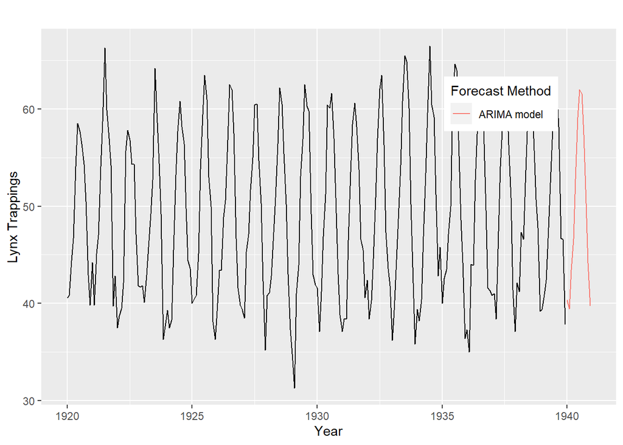

```r
mymodel = auto.arima(nottem )
myforecast = forecast(mymodel, h = 12)

autoplot(nottem) +
  forecast::autolayer(myforecast$mean, series = 'ARIMA model') +
  xlab('Year') + ylab('Lynx Trappings') +
  guides(colour = guide_legend(title = 'Forecast Method')) +
  theme(legend.position = c(0.8, 0.8))
```

Bu sebeple zaman serileri analizinde zaman bileşenlerinin, serinin hareketlerini ve arındırılmış yeni serinin dağılımı en iyi şekilde analiz edip, model oluşturmak önemlidir.